# 🎓 Master of Science in Applied Data Science 🎓

## 🤖 Machine Learning and Predictive Analytics 🤖

## 📅 Week 5: Simulate the Neurons in Your Brain with BackProp 📅

## 📝 Instructions

- **Purpose:** This assignment focuses on creating a Multi-Layer Perceptron (MLP) using scikit-learn to make predictions on the MNIST dataset. You'll delve into the concepts of Artificial Neural Networks (ANN), activation functions, loss functions, gradient descent, and backpropagation.
- **Prerequisites:**
  - Completion of Week 4 assignments and lessons.
  - Understanding of basic neural network concepts.
  - Familiarity with Python and scikit-learn.
- **Completing the Assignment:**
  - Complete all questions and sub-parts.
  - Point values indicate relative weighting.

**Tips**

- **Collaborate:** Discuss, but submit your own work. 🤝
- **Experiment:** Tweak parameters to understand their impact on model performance. 🧪
- **Ask for Help:** Reach out to your instructor/TA for guidance if stuck. 💡

## ❓ Question 1: Multi-Layer Perceptron (MLP) Implementation (40 points)

### Part A: Data Loading and Preprocessing

1. **Import:** Load necessary libraries

```python
# Import necessary libraries
import pandas as pd
import numpy as np
import matplotlib.pyplot as plt
import seaborn as sns
from sklearn.model_selection import train_test_split
from sklearn.preprocessing import MinMaxScaler
from sklearn.neural_network import MLPClassifier
from sklearn.metrics import confusion_matrix
```

### Part A: Data Loading and Preprocessing

2. **Dataset Loading:** Load the dataset labeled `Week_5_Train.csv` into a Pandas DataFrame.

```python
# Write your code here
df = pd.read_csv("/Users/edwinhsu/Assignment/Machine Learning & Predictive Analytics/Week_5_Train.csv")
df
```

|  | class | pixel1 | pixel2 | pixel3 | pixel4 | pixel5 | pixel6 | pixel7 | pixel8 | pixel9 | ... | pixel775 | pixel776 | pixel777 | pixel778 | pixel779 | pixel780 | pixel781 | pixel782 | pixel783 | pixel784 |
| --- | --- | --- | --- | --- | --- | --- | --- | --- | --- | --- | --- | --- | --- | --- | --- | --- | --- | --- | --- | --- | --- |
| 0 | 5 | 0 | 0 | 0 | 0 | 0 | 0 | 0 | 0 | 0 | ... | 0 | 0 | 0 | 0 | 0 | 0 | 0 | 0 | 0 | 0 |
| 1 | 4 | 0 | 0 | 0 | 0 | 0 | 0 | 0 | 0 | 0 | ... | 0 | 0 | 0 | 0 | 0 | 0 | 0 | 0 | 0 | 0 |
| 2 | 8 | 0 | 0 | 0 | 0 | 0 | 0 | 0 | 0 | 0 | ... | 0 | 0 | 0 | 0 | 0 | 0 | 0 | 0 | 0 | 0 |
| 3 | 0 | 0 | 0 | 0 | 0 | 0 | 0 | 0 | 0 | 0 | ... | 0 | 0 | 0 | 0 | 0 | 0 | 0 | 0 | 0 | 0 |
| 4 | 2 | 0 | 0 | 0 | 0 | 0 | 0 | 0 | 0 | 0 | ... | 0 | 0 | 0 | 0 | 0 | 0 | 0 | 0 | 0 | 0 |
| ... | ... | ... | ... | ... | ... | ... | ... | ... | ... | ... | ... | ... | ... | ... | ... | ... | ... | ... | ... | ... | ... |
| 55995 | 6 | 0 | 0 | 0 | 0 | 0 | 0 | 0 | 0 | 0 | ... | 0 | 0 | 0 | 0 | 0 | 0 | 0 | 0 | 0 | 0 |
| 55996 | 6 | 0 | 0 | 0 | 0 | 0 | 0 | 0 | 0 | 0 | ... | 0 | 0 | 0 | 0 | 0 | 0 | 0 | 0 | 0 | 0 |
| 55997 | 1 | 0 | 0 | 0 | 0 | 0 | 0 | 0 | 0 | 0 | ... | 0 | 0 | 0 | 0 | 0 | 0 | 0 | 0 | 0 | 0 |
| 55998 | 0 | 0 | 0 | 0 | 0 | 0 | 0 | 0 | 0 | 0 | ... | 0 | 0 | 0 | 0 | 0 | 0 | 0 | 0 | 0 | 0 |
| 55999 | 0 | 0 | 0 | 0 | 0 | 0 | 0 | 0 | 0 | 0 | ... | 0 | 0 | 0 | 0 | 0 | 0 | 0 | 0 | 0 | 0 |

56000 rows × 785 columns

```python
df.dtypes
```

```
class       int64
pixel1      int64
pixel2      int64
pixel3      int64
pixel4      int64
            ...
pixel780    int64
pixel781    int64
pixel782    int64
pixel783    int64
pixel784    int64
Length: 785, dtype: object
```

3. **Data Preprocessing:** Prepare the dataset for modeling. Assuming your data is in a DataFrame named 'df' with the target in column `class`, split into `X` and `y`:

```python
from sklearn.preprocessing import StandardScaler, LabelEncoder
# Separate the features and target variable
X = df.drop(columns=['class'])
y = df['class']
```

4. **Train/Test Split:** Split your data into `X_train`, `X_test`, `y_train`, and `y_test`

```python
# Train/Test Split
X_train, X_test, y_train, y_test = train_test_split(X, y, test_size=0.2, random_state=42)

X_train.shape, X_test.shape, y_train.shape, y_test.shape
```

```
((44800, 784), (11200, 784), (44800,), (11200,))
```

4. **Exploratory Data Analysis (EDA) for Preprocessing**

Perform exploratory data analysis (EDA) on the MNIST dataset. Specifically, get a sense of the distribution of the data and also create a histogram of pixel intensity values for a sample image from the dataset.

```python
print("Distribution of classes:")
print(y.value_counts())
```

```
Distribution of classes:
class
1    6277
7    5790
3    5708
2    5610
0    5560
9    5538
4    5529
6    5480
8    5468
5    5040
Name: count, dtype: int64
```

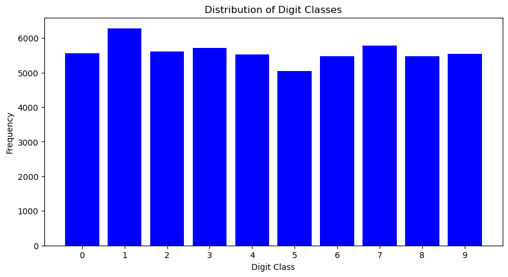

```python
# Show the distribution of the classes
unique, counts = np.unique(y, return_counts=True)
plt.figure(figsize=(10, 5))
plt.bar(unique, counts, color='blue')
plt.title('Distribution of Digit Classes')
plt.xlabel('Digit Class')
plt.ylabel('Frequency')
plt.xticks(unique)
plt.show()
```

```python
X
```

|  | pixel1 | pixel2 | pixel3 | pixel4 | pixel5 | pixel6 | pixel7 | pixel8 | pixel9 | pixel10 | ... | pixel775 | pixel776 | pixel777 | pixel778 | pixel779 | pixel780 | pixel781 | pixel782 | pixel783 | pixel784 |
| --- | --- | --- | --- | --- | --- | --- | --- | --- | --- | --- | --- | --- | --- | --- | --- | --- | --- | --- | --- | --- | --- |
| 0 | 0 | 0 | 0 | 0 | 0 | 0 | 0 | 0 | 0 | 0 | ... | 0 | 0 | 0 | 0 | 0 | 0 | 0 | 0 | 0 | 0 |
| 1 | 0 | 0 | 0 | 0 | 0 | 0 | 0 | 0 | 0 | 0 | ... | 0 | 0 | 0 | 0 | 0 | 0 | 0 | 0 | 0 | 0 |
| 2 | 0 | 0 | 0 | 0 | 0 | 0 | 0 | 0 | 0 | 0 | ... | 0 | 0 | 0 | 0 | 0 | 0 | 0 | 0 | 0 | 0 |
| 3 | 0 | 0 | 0 | 0 | 0 | 0 | 0 | 0 | 0 | 0 | ... | 0 | 0 | 0 | 0 | 0 | 0 | 0 | 0 | 0 | 0 |
| 4 | 0 | 0 | 0 | 0 | 0 | 0 | 0 | 0 | 0 | 0 | ... | 0 | 0 | 0 | 0 | 0 | 0 | 0 | 0 | 0 | 0 |
| ... | ... | ... | ... | ... | ... | ... | ... | ... | ... | ... | ... | ... | ... | ... | ... | ... | ... | ... | ... | ... | ... |
| 55995 | 0 | 0 | 0 | 0 | 0 | 0 | 0 | 0 | 0 | 0 | ... | 0 | 0 | 0 | 0 | 0 | 0 | 0 | 0 | 0 | 0 |
| 55996 | 0 | 0 | 0 | 0 | 0 | 0 | 0 | 0 | 0 | 0 | ... | 0 | 0 | 0 | 0 | 0 | 0 | 0 | 0 | 0 | 0 |
| 55997 | 0 | 0 | 0 | 0 | 0 | 0 | 0 | 0 | 0 | 0 | ... | 0 | 0 | 0 | 0 | 0 | 0 | 0 | 0 | 0 | 0 |
| 55998 | 0 | 0 | 0 | 0 | 0 | 0 | 0 | 0 | 0 | 0 | ... | 0 | 0 | 0 | 0 | 0 | 0 | 0 | 0 | 0 | 0 |
| 55999 | 0 | 0 | 0 | 0 | 0 | 0 | 0 | 0 | 0 | 0 | ... | 0 | 0 | 0 | 0 | 0 | 0 | 0 | 0 | 0 | 0 |

56000 rows × 784 columns

```python
y
```

```
0        5
1        4
2        8
3        0
4        2
        ..
55995    6
55996    6
55997    1
55998    0
55999    0
Name: class, Length: 56000, dtype: int64
```

```python
X.iloc[0]
```

```
pixel1      0
pixel2      0
pixel3      0
pixel4      0
pixel5      0
           ..
pixel780    0
pixel781    0
pixel782    0
pixel783    0
pixel784    0
Name: 0, Length: 784, dtype: int64
```

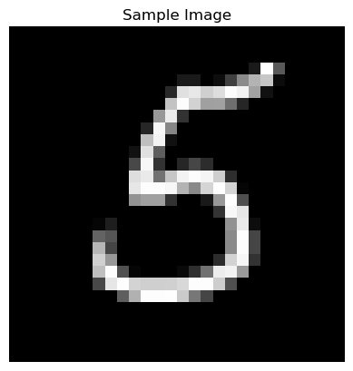

```python
# Reshape the first image data to 28x28 and display the image
sample_image = X.iloc[0].values.reshape(28, 28)

# Plot the sample image
plt.imshow(sample_image, cmap='gray')
plt.title('Sample Image')
plt.axis('off')
plt.show()
```

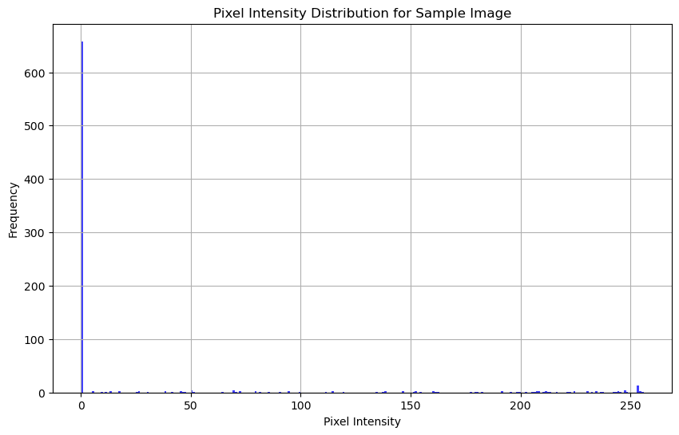

```python
# Plotting the histogram of pixel intensity values for the sample image
plt.figure(figsize=(10, 6))
plt.hist(sample_image.ravel(), bins=256, range=[0,256], color='blue', alpha=0.75)
plt.title('Pixel Intensity Distribution for Sample Image')
plt.xlabel('Pixel Intensity')
plt.ylabel('Frequency')
plt.grid(True)
plt.show()
```

4. **Preprocessing:** Rescale the features to have values between 0 and 1 using `MinMaxScaler`.

```python
# Initialize the MinMaxScaler to scale features between 0 and 1
scaler = MinMaxScaler(feature_range=(0, 1))

# Fit the scaler on the training data
scaler.fit(X_train)

# Transform both the training and testing data
X_train_scaled = scaler.transform(X_train)
X_test_scaled = scaler.transform(X_test)
```

```python
X_train_scaled
```

```
array([[0., 0., 0., ..., 0., 0., 0.],
       [0., 0., 0., ..., 0., 0., 0.],
       [0., 0., 0., ..., 0., 0., 0.],
       ...,
       [0., 0., 0., ..., 0., 0., 0.],
       [0., 0., 0., ..., 0., 0., 0.],
       [0., 0., 0., ..., 0., 0., 0.]])
```

### Part B: MLP Implementation

1. **Create MLP Classifier:** Instantiate an MLP classifier object with the default settings.

```python
from sklearn.neural_network import MLPClassifier

# Create an MLP classifier with the default settings
mlp = MLPClassifier(random_state=42)
```

2. **Fit Classifier:** Use the `fit` method of the MLP Classifier object to train the model on the training data. Pass the training features and corresponding labels as arguments to the `fit` method.

```python
# Fit the MLP classifier to the scaled training data
mlp.fit(X_train_scaled, y_train)
```

```
MLPClassifier(random_state=42)
```

3. **Evaluate Performance:** Use the `score` method of the MLP Classifier object to calculate the accuracy of the trained model on the test set. Pass the test features and corresponding labels as arguments to the `score` method.

```python
# Evaluate the performance on the test set
test_accuracy = mlp.score(X_test_scaled, y_test)

print(f"Accuracy of the MLP classifier on the test set: {test_accuracy:.2f}")
```

```
Accuracy of the MLP classifier on the test set: 0.97
```

4. **Plot Confusion Matrix:** Use the `confusion_matrix` function from scikit-learn to generate the confusion matrix. Visualize the confusion matrix as a heatmap using seaborns's `.heatmap()` function. Customize the plot to make it visually appealing, including labels for classes and axes, colorbar, and appropriate color mapping.

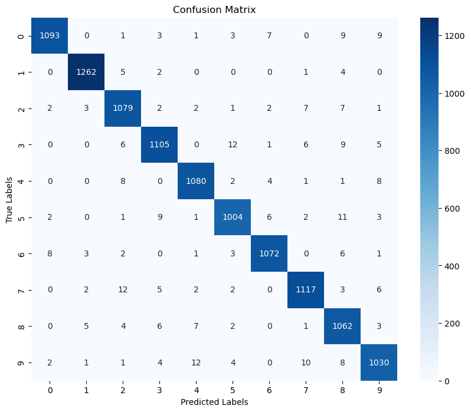

```python
from sklearn.metrics import confusion_matrix
import seaborn as sns
import matplotlib.pyplot as plt

# First, we'll need to make predictions on the test set
y_pred = mlp.predict(X_test_scaled)

# Generate the confusion matrix
cm = confusion_matrix(y_test, y_pred)

# Get unique labels from the test set
unique_labels = np.unique(y_test).astype(str)

# Plot the confusion matrix using Seaborn's heatmap()
plt.figure(figsize=(10, 8))
sns.heatmap(cm, annot=True, fmt='d', cmap='Blues', cbar=True, xticklabels=unique_labels, yticklabels=unique_labels)
plt.title('Confusion Matrix')
plt.xlabel('Predicted Labels')
plt.ylabel('True Labels')
plt.show()
```

**5. Based on the visualization of the confusion matrix, analyze the mistakes made by the Neural Network:**

- Identify areas where the Neural Network is making mistakes, such as misclassifying certain digits.
- Are there specific pairs of digits that the model frequently confuses with each other?
- Do the misclassifications make sense? For example, consider digits that have similar shapes or are visually ambiguous.
- Are there any patterns or trends in the misclassifications that could provide insights into potential improvements to the model?

The entries along the diagonal of the confusion matrix represent correct classifications. High numbers along the diagonal, which are apparent in the image, indicate that the neural network is performing well for the majority of instances.

However, we still can spot specific pairs of digits that are commonly misclassifiedin in the confusion matrix.

3 misclassified as 5: The curved shape of 3 could be mistaken for 5 if the middle part of the '3' is not pronounced. Additional training data or augmentation that emphasizes the separation of the two curves in '3' could help. 5 misclassified as 8: This might happen if the top part of '5' is too round, making it resemble an '8'. Focusing on the distinction between the upper and lower parts of '5' in the training data can assist in reducing this error. 7 misclassified as 2: If the horizontal stroke of the '7' is not clear or if it's written with an additional curve, it could be mistaken for a '2'. Including clearer examples of '7' and '2' with distinct features in the training set might help the model distinguish them better. 9 misclassified as 4: A '9' with a short stem could be confused with a '4'. Training the model to recognize the round part of the '9' and the triangular shape of '4' more distinctly could improve performance.

The misclassifications we observed suggest certain patterns and trends which could be related to the visual similarities and ambiguities between the digits.

# ✍️ Respond to the question in this markdown cell ✍️

## Question 2: Experimentation and Analysis (30 points)

### **Part A: Activation Functions**

1. **Experimentation:** Implement MLP Classifiers with different activation functions (e.g., logistic, tanh, relu) in the hidden layers. Train each model on the training data and evaluate their performance on the test set.

```python
from sklearn.metrics import accuracy_score, confusion_matrix
import seaborn as sns
import matplotlib.pyplot as plt

# Define the activation functions available in scikit-learn's MLPClassifier
activation_functions = ['identity', 'logistic', 'tanh', 'relu']

# Dictionary to store models and metrics
models_metrics = {}

# Train a model for each activation function and evaluate performance
for activation in activation_functions:
    mlp = MLPClassifier(activation=activation, random_state=42, max_iter=1000)
    mlp.fit(X_train_scaled, y_train)

    # Predict on the test set
    y_pred = mlp.predict(X_test_scaled)

    # Calculate accuracy and confusion matrix
    accuracy = accuracy_score(y_test, y_pred)
    cm = confusion_matrix(y_test, y_pred)

    # Store the model and its metrics
    models_metrics[activation] = {
        'model': mlp,
        'accuracy': accuracy,
        'confusion_matrix': cm
    }
```

2. **Quantitative Analysis:** Compare the performance metrics (e.g., accuracy, confusion matrix) of the MLP Classifiers with different activation functions. Identify which activation function(s) yield the best performance for the given dataset.

```
Accuracy with identity activation: 0.9133
```

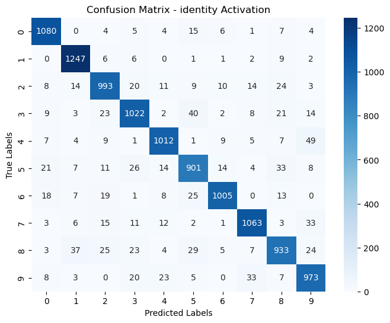

```
Accuracy with logistic activation: 0.9738
```

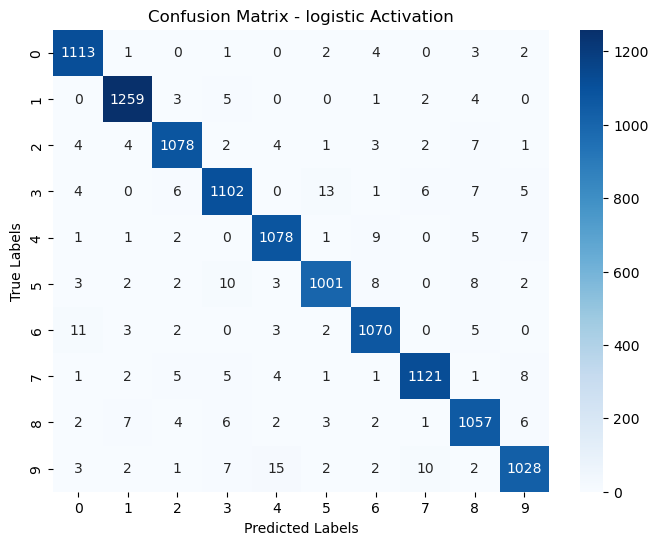

```
Accuracy with tanh activation: 0.9741
```

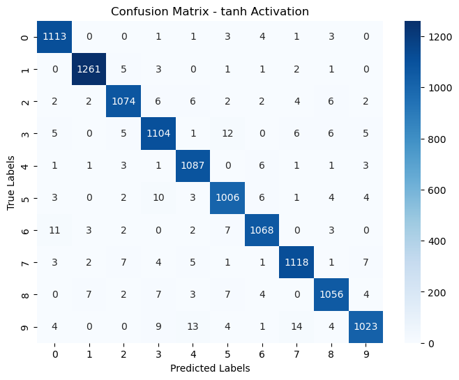

```
Accuracy with relu activation: 0.9736
```

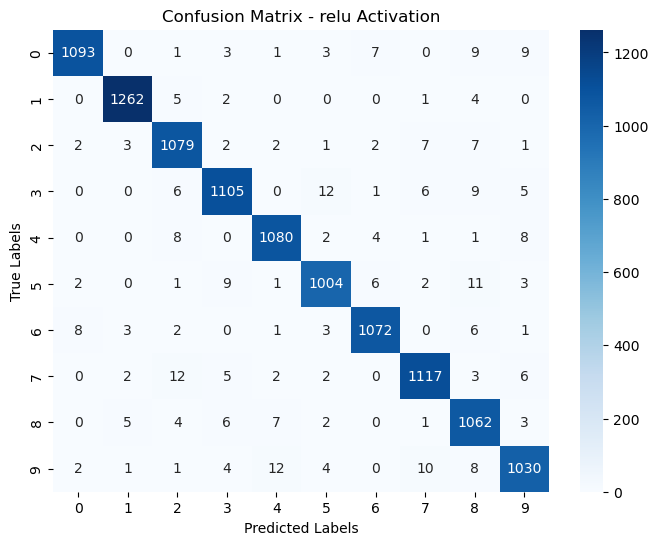

```python
# Now, print the accuracy for each activation function and plot confusion matrices
for activation, metrics in models_metrics.items():
    print(f'Accuracy with {activation} activation: {metrics["accuracy"]:.4f}')

    # Plot the confusion matrix
    plt.figure(figsize=(8, 6))
    sns.heatmap(metrics['confusion_matrix'], annot=True, fmt='d', cmap='Blues', cbar=True)
    plt.title(f'Confusion Matrix - {activation} Activation')
    plt.xlabel('Predicted Labels')
    plt.ylabel('True Labels')
    plt.show()
```

3. **Explain:** Discuss the impact of different activation functions on the model's performance.

**Identity Activation (0.9133 Accuracy):** The identity activation function does not apply any transformation to the input data. It's effectively a linear activation which limits the neural network to linear transformations. This means the network with identity activation can only represent linear decision boundaries. The lower performance suggests that the problem at hand is not linearly separable and requires the model to capture non-linear relationships to improve accuracy.

**Logistic Activation (0.9738 Accuracy):** Also known as the sigmoid function, squashes the input values into a range between 0 and 1. It can lead to a neural network capable of learning non-linear decision boundaries, which is critical for tasks like image recognition. However, it is susceptible to vanishing gradients, meaning that neurons can become 'stuck' during training if inputs are very large or small. Despite this, the logistic function has performed quite well in this instance.

**Tanh Activation (0.9741 Accuracy):** The hyperbolic tangent (tanh) function is similar to the logistic sigmoid but transforms input values to a range between -1 and 1. This means it is zero-centered, which generally makes optimization easier and leads to faster convergence. The tanh function has the highest accuracy among the activation functions tested, albeit by a very slim margin. This suggests that the non-linear transformations it applies are slightly more beneficial for this dataset.

**ReLU Activation (0.9736 Accuracy):** The rectified linear unit (ReLU) function outputs the input directly if it is positive; otherwise, it outputs zero. This function has performed comparably to the logistic and tanh functions, which indicates that it is effectively capturing the non-linearities in the dataset. However, it could be susceptible to the dying ReLU problem, where neurons can become inactive and only output zero.

# ✍️ Respond to the question in this markdown cell ✍️

### **Part B: Gradient Descent Optimization**

1. **Experimentation:** Implement the MLP Classifier that had the best accuracy for both the activation function and loss function with different optimization algorithms (e.g., adam, sgd, lbfgs). Train each model on the training data and evaluate their performance on the test set.

```python
# The best activation function from the previous experiments
best_activation = 'tanh'

# Define a list of solvers to experiment with
solvers = ['adam', 'sgd', 'lbfgs']

# Dictionary to store models, their performance metrics, and confusion matrices
models_performance = {}

# Train an MLPClassifier with each solver and the best activation function
for solver in solvers:
    mlp = MLPClassifier(activation=best_activation, solver=solver, random_state=42, max_iter=1000)
    mlp.fit(X_train_scaled, y_train)

    # Predict on the test set
    y_pred = mlp.predict(X_test_scaled)

    # Calculate accuracy
    accuracy = accuracy_score(y_test, y_pred)

    # Calculate the confusion matrix
    cm = confusion_matrix(y_test, y_pred)

    # Store the model, accuracy, and confusion matrix
    models_performance[solver] = {
        'model': mlp,
        'accuracy': accuracy,
        'confusion_matrix': cm
    }
```

2. **Quantitative Analysis:** Compare the performance metrics (e.g., accuracy, confusion matrix) of the MLP Classifiers with different optimization algorithms. Identify which optimization algorithm(s) yield the best performance for the given dataset.

```
Accuracy with adam solver: 0.9741
```

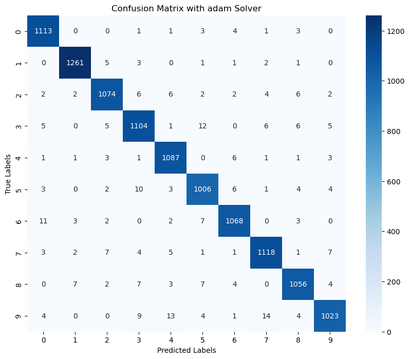

```
Accuracy with sgd solver: 0.9706
```

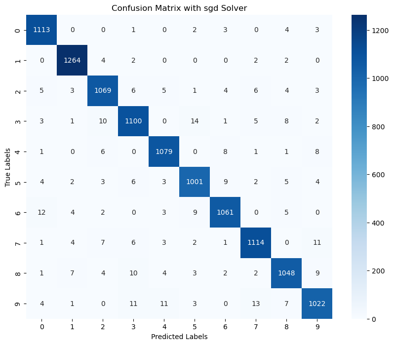

```
Accuracy with lbfgs solver: 0.9680
```

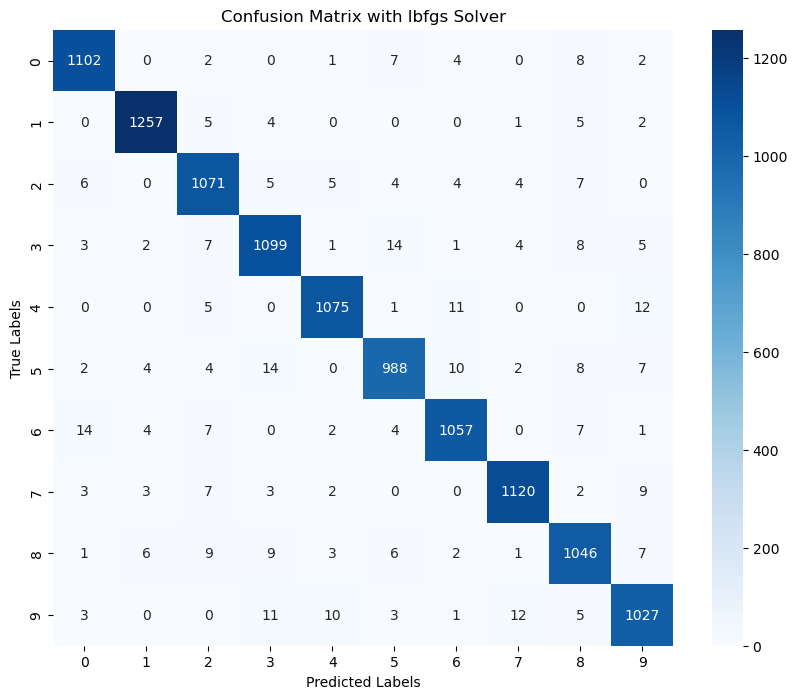

```python
# Output the performance metrics and plot the confusion matrices
for solver, performance in models_performance.items():
    print(f'Accuracy with {solver} solver: {performance["accuracy"]:.4f}')

    # Plot the confusion matrix
    plt.figure(figsize=(10, 8))
    sns.heatmap(performance['confusion_matrix'], annot=True, fmt='d', cmap='Blues', cbar=True)
    plt.title(f'Confusion Matrix with {solver} Solver')
    plt.xlabel('Predicted Labels')
    plt.ylabel('True Labels')
    plt.show()
```

3. **Explain:** Discuss the impact of different gradient descent algorithms on the model's performance.
- **Adam (Accuracy: 0.9741):** Adaptive Moment Estimation (Adam) combines the advantages of two other extensions of stochastic gradient descent: Adaptive Gradient Algorithm (AdaGrad) and Root Mean Square Propagation (RMSProp).  
  Impact: Adam's strength lies in its adaptability to different data types and its robustness against vanishing or exploding gradients. Its performance as shown in our results, achieving the highest accuracy, suggests it navigated the problem space efficiently, adjusting its learning rates to converge smoothly to a good solution.
- **SGD (Accuracy: 0.9706):** Stochastic Gradient Descent (SGD) updates the model's weights using a random sample of data rather than the full dataset at each iteration. This can make SGD faster for very large datasets and can also introduce a beneficial level of noise, helping to escape local minima. Impact: The slightly lower performance of SGD compared to Adam might be due to its reliance on a fixed learning rate or it could require more careful tuning of the learning rate and momentum parameters. Without an adaptive learning rate, SGD might not always converge as efficiently as Adam, particularly on complex datasets where different features might benefit from different learning rate adjustments.
- **LBFGS (Accuracy: 0.9680):** By definition, Limited-memory Broyden–Fletcher–Goldfarb–Shanno (LBFGS) Algorithm is a quasi-Newton method that approximates the Broyden–Fletcher–Goldfarb–Shanno algorithm, which uses a full approximation of the second-order Hessian matrix to guide its search for the minimum. Impact: LBFGS is more memory-efficient than the true BFGS and often performs well on small to medium-sized datasets. However, its lower performance here might be due to the complexity and potentially non-convex nature of the optimization landscape in deep neural networks. LBFGS does not deal with noise as robustly as stochastic methods like Adam and SGD, which can be advantageous in finding global minima for complex functions.
- **Summary:** The differences in performance are attributed to how each algorithm deals with the error landscape of the model. Adam proves to be highly efficient and robust in handling non-linear data transformations due to its adaptive learning rates. SGD is generally reliable and can be very effective but may require more iterations or careful parameter tuning to match the performance of more sophisticated optimizers. LBFGS might struggle with larger, more complex datasets typically found in deep learning contexts, despite being powerful in scenarios with simpler or smaller datasets.

# ✍️ Respond to the question in this markdown cell ✍️

## Question 3: Regularization and Hidden Layers (30 points)

### **Part A: Regularization**

1. **Experimentation:** Implement the MLP Classifier that had the best accuracy for both the activation function and optimization algorithm with different L2 regularization. Train each model on the training data and evaluate their performance on the test set.

```python
# Best activation function and optimizer from previous tests
best_activation = 'tanh'
best_solver = 'adam'

# Define a range of alpha values to experiment with
alpha_values = [0.0001, 0.001, 0.01, 0.1, 1]

# Dictionary to store models and their performance metrics
models_performance = {}

# Train an MLPClassifier with each alpha value
for alpha in alpha_values:
    mlp = MLPClassifier(activation=best_activation, solver=best_solver, alpha=alpha, random_state=42, max_iter=1000)
    mlp.fit(X_train_scaled, y_train)

    # Predict on the test set
    y_pred = mlp.predict(X_test_scaled)

    # Calculate accuracy
    accuracy = accuracy_score(y_test, y_pred)

    # Calculate the confusion matrix
    cm = confusion_matrix(y_test, y_pred)

    # Store the model, accuracy, and confusion matrix
    models_performance[alpha] = {
        'model': mlp,
        'accuracy': accuracy,
        'confusion_matrix': cm
    }
```

2. **Quantitative Analysis:** Compare the performance metrics (e.g., accuracy, confusion matrix) of the MLP Classifiers with different L2 regularization (alpha). Identify which yielded the best performance for the given dataset.

```
Accuracy with alpha = 0.0001: 0.9741
```

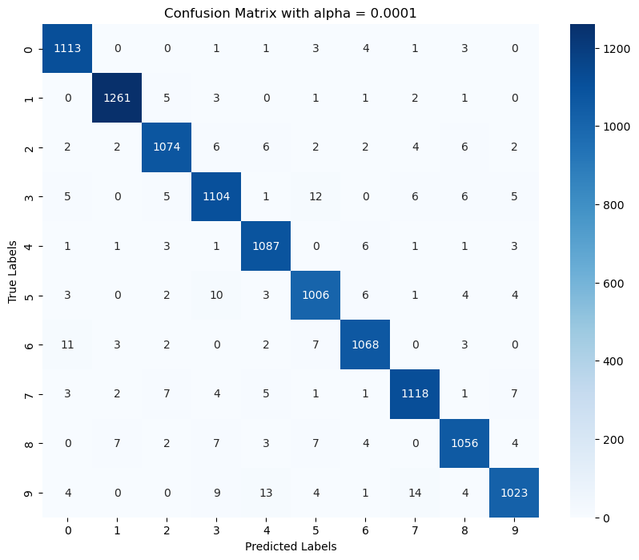

```
Accuracy with alpha = 0.001: 0.9640
```

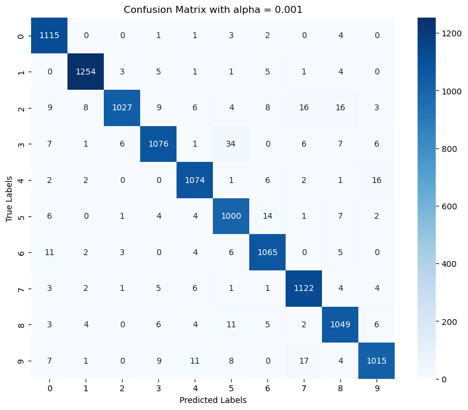

```
Accuracy with alpha = 0.01: 0.9747
```

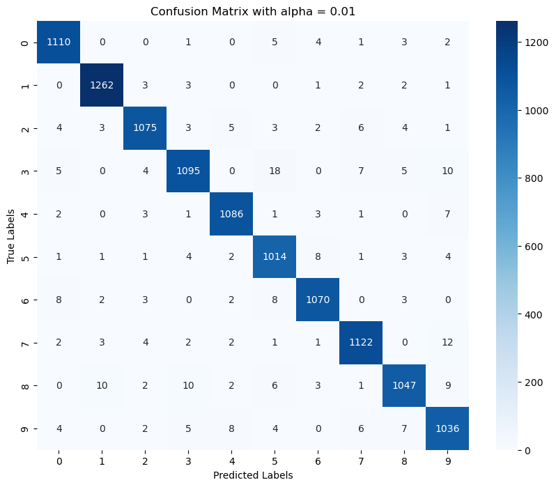

```
Accuracy with alpha = 0.1: 0.9729
```

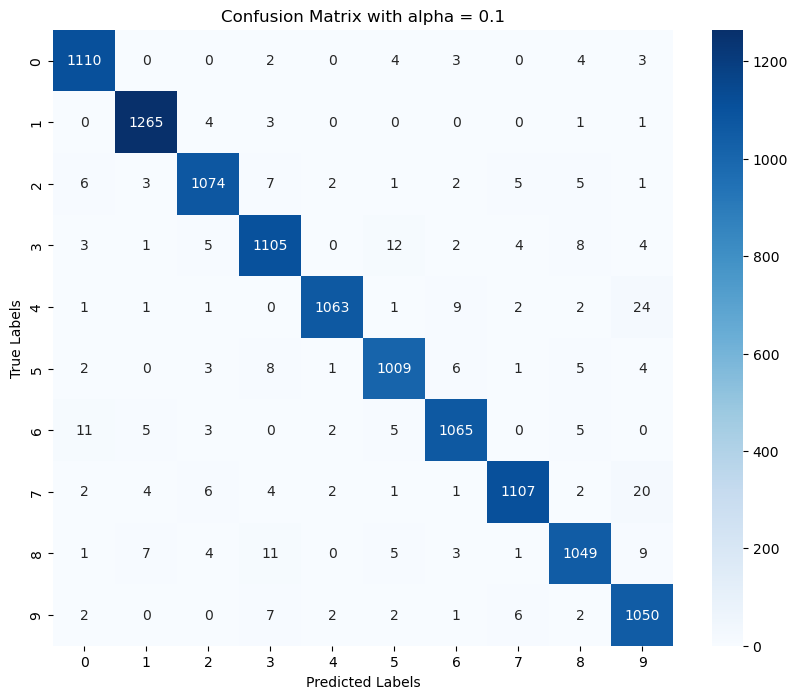

```
Accuracy with alpha = 1: 0.9419
```

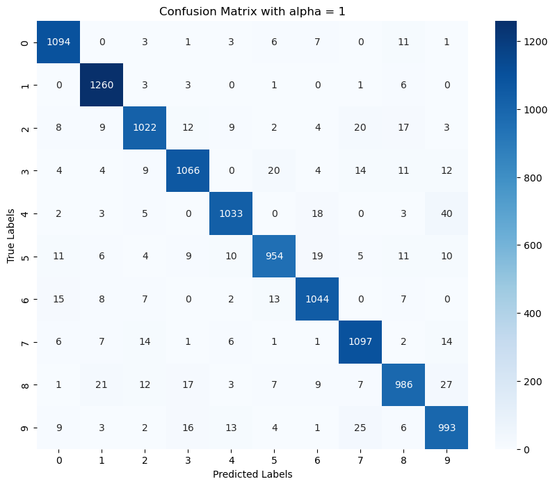

```python
# Output the performance metrics and plot the confusion matrices
for alpha, performance in models_performance.items():
    print(f'Accuracy with alpha = {alpha}: {performance["accuracy"]:.4f}')

    # Plot the confusion matrix
    plt.figure(figsize=(10, 8))
    sns.heatmap(performance['confusion_matrix'], annot=True, fmt='d', cmap='Blues', cbar=True)
    plt.title(f'Confusion Matrix with alpha = {alpha}')
    plt.xlabel('Predicted Labels')
    plt.ylabel('True Labels')
    plt.show()
```

3. **Explain:** Discuss the impact of different regularization (L2) values on the model's performance.
- **Alpha = 0.0001 (Accuracy: 0.9741):** Very Low Regularization: This setting provides minimal regularization, which allows the model to fit the training data closely. Since the accuracy is high, it indicates that the model has enough capacity to learn the data patterns without significant overfitting, given the regularization is almost negligible.
- **Alpha = 0.001 (Accuracy: 0.9640):** Low Regularization: Increasing the regularization slightly to 0.001 seems to slightly degrade the model's performance compared to the very low setting. This might suggest that the added regularization is slightly too restrictive, penalizing the model's ability to fit the data effectively.
- **Alpha = 0.01 (Accuracy: 0.9747:)** Moderate Regularization: Surprisingly, increasing the regularization further to 0.01 leads to a slight improvement in accuracy, the highest in the series. This indicates an optimal balance between bias and variance, suggesting that this level of regularization effectively prevents overfitting while still allowing the model to capture essential patterns in the data.
- **Alpha = 0.1 (Accuracy: 0.9729):** High Regularization: As the regularization strength increases to 0.1, there's a slight drop in accuracy compared to the optimal 𝛼 = 0.01. This suggests that while the model is still performing well, the stronger regularization might be starting to introduce too much bias, preventing the model from fitting the data as closely as it could.
- **Alpha = 1 (Accuracy: 0.9419):** Very High Regularization: With 𝛼 = 1, there's a significant drop in accuracy, indicating that the regularization is now too strong. The model is likely underfitting, meaning that it's overly penalized and unable to capture the underlying patterns and complexities of the dataset.

### Summary

The optimal performance at 𝛼 = 0.01 suggests that a moderate level of regularization helps in mitigating overfitting without significantly constraining the model’s capacity to learn the underlying patterns in the data. Very high values of 𝛼 lead to underfitting, where the model becomes too simple to explain the variability in the data. Very low values, conversely, might allow the model to overfit, fitting too closely to the noise in the training data rather than underlying trends.

# ✍️ Respond to the question in this markdown cell ✍️

### **Part B: Hidden Layers**

1. **Experimentation:** Implement MLP Classifiers with different configurations of hidden layers, including models with one hidden layer and models with two hidden layers. Train each model on the training data and evaluate their performance on the test set.

```python
# Define different configurations for hidden layers
hidden_layer_sizes = [
    (50,),          # One hidden layer with 50 neurons
    (100,),         # One hidden layer with 100 neurons
    (50, 50),       # Two hidden layers, each with 50 neurons
    (100, 100),     # Two hidden layers, each with 100 neurons
    (100, 50),      # Two hidden layers with 100 neurons in the first and 50 in the second
    (50, 100)       # Two hidden layers with 50 neurons in the first and 100 in the second
]

# Dictionary to store models and their performance metrics
models_performance = {}

# Train an MLPClassifier with each hidden layer configuration
for hidden_layers in hidden_layer_sizes:
    mlp = MLPClassifier(hidden_layer_sizes=hidden_layers, activation='relu', solver='adam', random_state=42, max_iter=1000)
    mlp.fit(X_train_scaled, y_train)

    # Predict on the test set
    y_pred = mlp.predict(X_test_scaled)

    # Calculate accuracy
    accuracy = accuracy_score(y_test, y_pred)

    # Calculate the confusion matrix
    cm = confusion_matrix(y_test, y_pred)

    # Store the model, accuracy, and confusion matrix
    models_performance[hidden_layers] = {
        'model': mlp,
        'accuracy': accuracy,
        'confusion_matrix': cm
    }
```

2. **Quantitative Analysis:** Compare the performance metrics (e.g., accuracy, confusion matrix) of the MLP Classifiers with different configurations of hidden layers. Identify whether adding an additional hidden layer leads to improved accuracy and better generalization performance.

```
Accuracy with hidden layers (50,): 0.9650
```

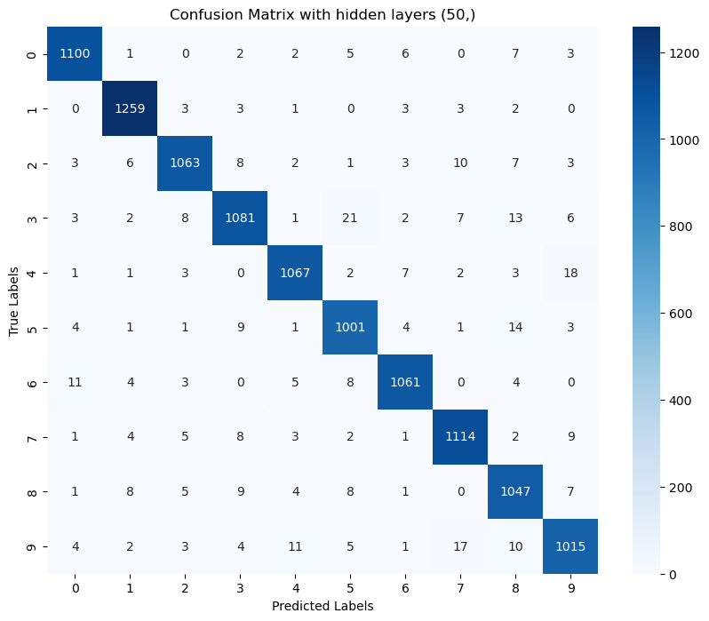

```
Accuracy with hidden layers (100,): 0.9736
```

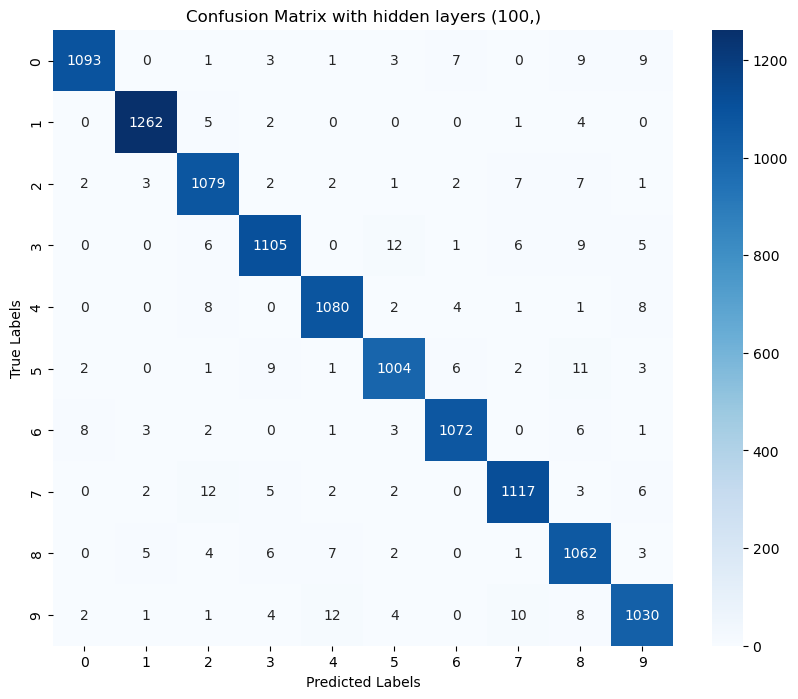

```
Accuracy with hidden layers (50, 50): 0.9698
```

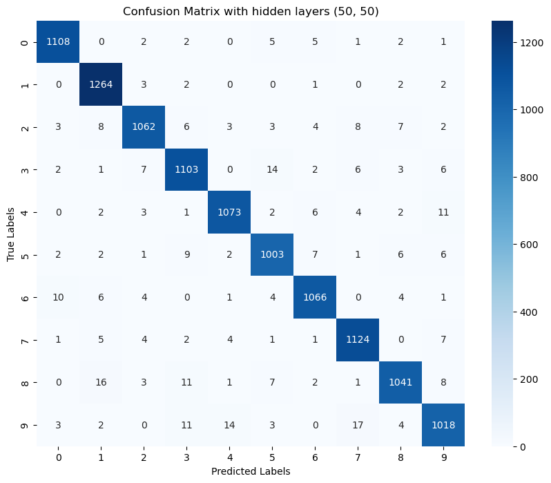

```
Accuracy with hidden layers (100, 100): 0.9768
```

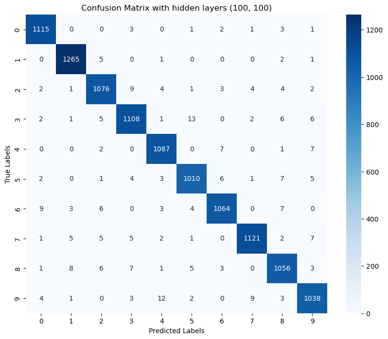

```
Accuracy with hidden layers (100, 50): 0.9759
```

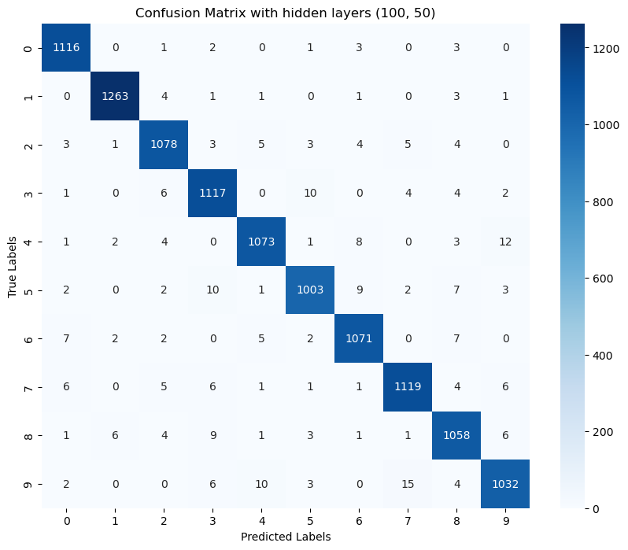

```
Accuracy with hidden layers (50, 100): 0.9730
```

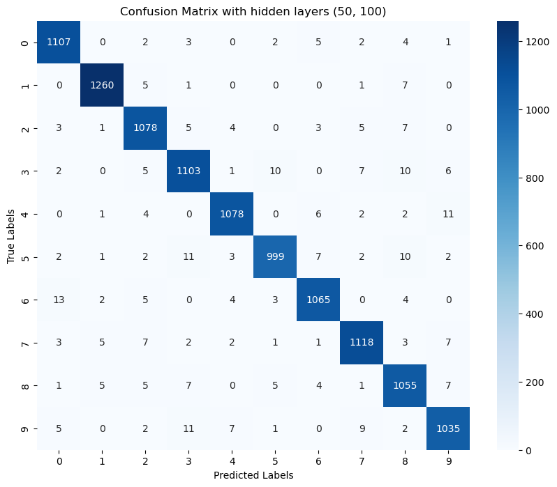

```python
# Output the performance metrics and plot the confusion matrices
for hidden_layers, performance in models_performance.items():
    print(f'Accuracy with hidden layers {hidden_layers}: {performance["accuracy"]:.4f}')

    # Plot the confusion matrix
    plt.figure(figsize=(10, 8))
    sns.heatmap(performance['confusion_matrix'], annot=True, fmt='d', cmap='Blues', cbar=True)
    plt.title(f'Confusion Matrix with hidden layers {hidden_layers}')
    plt.xlabel('Predicted Labels')
    plt.ylabel('True Labels')
    plt.show()
```

3. **Explain:** Discuss the impact of different using different combinations of neurons and hidden layers had on the model's performance.

### Single Hidden Layer Configurations

- **(50,): Accuracy = 0.9650** A single hidden layer with 50 neurons is the simplest model among those tested. The relatively lower accuracy suggests that this configuration might not have sufficient capacity to capture the complexity of the data. It likely underfits the dataset.
- **(100,): Accuracy = 0.9736** Doubling the neurons in a single hidden layer to 100 significantly improves accuracy. This suggests that increasing the model's capacity by adding more neurons helps the network to better capture the data’s complexity and improve generalization.

### Two Hidden Layers Configurations

- **(50, 50): Accuracy = 0.9698** Two layers, each with 50 neurons, perform better than a single layer of 50 but not as well as a single layer of 100. This indicates that while adding layers does increase the model's ability to capture more complex patterns, merely splitting the same number of neurons across more layers doesn’t automatically result in better performance.
- **(100, 100): Accuracy = 0.9768** This configuration provides the best performance among the tested models. Two layers with 100 neurons each greatly increase the network's capacity, allowing it to learn more complex features at multiple levels of abstraction.
- **(100, 50): Accuracy = 0.9759** This model, where the first layer has more neurons than the second, also shows very high performance, slightly less than the (100, 100) configuration. It suggests that having a larger number of neurons in the first layer (which directly handles the input features) can effectively capture significant patterns, which are then refined by the second layer.
- **(50, 100): Accuracy = 0.9730** Inverting the configuration of the previous model to (50, 100) results in a slight decrease in accuracy compared to (100, 50). This might indicate that the initial capture of features is more critical and that having more neurons earlier in the network can be more beneficial.

### Summary

- **Capacity:** Adding more neurons and layers generally increases the neural network's capacity, which can be beneficial up to a point.
- **Layer Configuration:** The configuration of neurons across layers also plays a significant role. Models where the first layer is larger seem to perform better, suggesting the first layer's ability to capture a broad range of features is crucial.

The results indicate that for our dataset, a balance of depth and breadth in the network architecture—especially configurations that start with more neurons in the initial layer—tends to yield better performance, highlighting the importance of designing network architectures that align with the data's complexity.

# ✍️ Respond to the question in this markdown cell ✍️